# Wind processing with tidyverse - R Notebook

**Autore**: Giacomo Roversi

Laboratorio di Fisica dell’Atmosfera A.A. 2022/23

# Esperienza 1

## Inizializzazione

Per cominciare inizializziamo l’ambiente di calcolo: cancello eventuali variabili e carico i pacchetti necessari.

```r
# Clear the workspace
rm(list=ls())
```

```r
# Load packages
require(tidyverse)  # For most of the things shown here
require(lubridate)  # For date-time manipulations
require(zoo)        # For rolling functions (moving window)

tidyverse_logo()
```

```
⬢ __  _    __   .    ⬡           ⬢  .
 / /_(_)__/ /_ ___  _____ _______ ___
/ __/ / _  / // / |/ / -_) __(_-</ -_)
\__/_/\_,_/\_, /|___/\__/_/ /___/\__/
     ⬢  . /___/      ⬡      .       ⬢
```

```r
# To see which packages are part of tidyverse:
tidyverse_packages()
```

```
 [1] "broom"         "cli"           "crayon"        "dbplyr"        "dplyr"         "dtplyr"
 [7] "forcats"       "ggplot2"       "googledrive"   "googlesheets4" "haven"         "hms"
[13] "httr"          "jsonlite"      "lubridate"     "magrittr"      "modelr"        "pillar"
[19] "purrr"         "readr"         "readxl"        "reprex"        "rlang"         "rstudioapi"
[25] "rvest"         "stringr"       "tibble"        "tidyr"         "xml2"          "tidyverse"
```

```r
# Define the working directory (in this case, the path is different depending on whether the code is executed on Linux or Windows, but just for my convenience)

if(Sys.info()["sysname"]=="Linux"){
  setwd("/home/giacom0rovers1/tutorLabFisAtm22/Esp_1/")
}else{
  setwd("C:/projects/tutorLabFisAtm22/Esp_1/")
}
```

### Definizione dei nomi dei files e delle cartelle

Genero tutti i nomi dei vari output del progetto partendo dalla variabile “radice” che imposto qui. L’ho chiamata `StationDataRootName`. Dichiaro tutto all’inizio del codice per non dover andare poi in cerca dei nomi se volessi fare delle modifiche. Distribuisco i files in tre cartelle: `datafolder` conterrà solo i dati grezzi in input, da non modificare, `resfolder` conterrà tutti i dati processati e i risultati, `figfolder` le figure.

```r
# Define the project directories (relative path)
datafolder <- "dati/"
figfolder  <- "figure/"
resfolder  <- "risultati/"

# Create the project directories, if missing
if(!dir.exists(datafolder)){ dir.create(datafolder) }
if(!dir.exists(figfolder)){  dir.create(figfolder) }
if(!dir.exists(resfolder)){  dir.create(resfolder) }

# Define the input filenames and assign them to a variable
StationDataRootName <- "Dati Meteo - Stazione A"

filenames <- list(
  input           = paste0(datafolder, StationDataRootName, ".txt"),

  # output.proc     = paste0(resfolder , StationDataRootName, "_proc.txt"),
  # output.ExcTIME  = paste0(resfolder , StationDataRootName, "_ExcTIME.txt"),
  # output.ExcWSneg = paste0(resfolder , StationDataRootName, "_ExcWSneg.txt"),
  # ouput.ExcWS3h   = paste0(resfolder , StationDataRootName, "_ExcWS3h.txt"),
  output.LAKES    = paste0(resfolder , StationDataRootName, "_LAKES.txt"),
  output.windData = paste0(resfolder, StationDataRootName, "_windData.RData"),

  figure.DataConsistency = paste0(figfolder, StationDataRootName, "_DataConsistency.png"),
  figure.HistWS          = paste0(figfolder, StationDataRootName, "_HistWS.png"),
  # figure.WindRose        = paste0(figfolder, StationDataRootName, "_WindRose.png"),
  figure.ScatterPlot     = paste0(figfolder, StationDataRootName, "_ScatterPlot.png"),
  figure.DailyWind       = paste0(figfolder, StationDataRootName, "_DailyWind.png")
)
```

Gli outputs su file leggibile (txt, csv) hanno senso solo se dobbiamo interfacciare linguaggi o software diversi, come nel caso di WRPLOT di Lakes, altrimenti conviene salvare i dati in un archivio dati compresso (in R hanno l’estensione `.RData`, equivalenti ad esempio ai `.mat` di Matlab.).

Gli outputs commentati si riferiscono a quei prodotti dello script *Codice R - Base per Wind Processing.R* che non sono stati riprodotti qui.

## Gestione dei dati

### Correzione dell’intestazione dei files di dati delle stazioni Davis

Leggo la prima riga e la spezzo dove ci sono le virgole, poi processo il risultato attraverso vari passaggi di sostituzione caratteri in modo da eliminare il cancelletto a inizio riga e i vari spazi vuoti rimasti. Salvo il tutto nella variabile “header”, che mi servirà tra poco.

```r
connection <- file(filenames$input)
open(connection)

header <- strsplit(readLines(connection, 1), ",")[[1]] %>%
  str_replace("#"    , "") %>%
  str_replace("     ", "") %>%
  str_replace("    " , "") %>%
  str_replace("   "  , "") %>%
  str_replace(" "    , "") %>%
  str_replace(" "    , "")

close(connection)
```

**Nota 1.** L’operatore `%>%` concatena l’output di una funzione come input della successiva (come l’operatore “pipe” `|` in bash ad esempio) . Solo le funzioni del pacchetto `tidyverse` sono predisposte per accettare questa concatenazione in input. Le funzioni base di R invece sono utilizzate nella prima riga nella classica forma innestata (“nested”), ovvero una dentro l’altra.

**Nota 2.** La funzione `strsplit()` restituisce come output una **lista** (vedi `?list`). La lista ha un solo elemento, costituito da un vettore di stringhe di caratteri, che sarebbero i vari pezzi in cui è stata suddivisa la prima riga del nostro file di input. Il suffisso `[[1]]` che compare dopo `strsplit()` serve a selezionare direttamente il vettore caratteri contenuto nella prima posizione della lista, invece che tutta la lista, che non sarebbe un input corretto per `str_replace()`.

### Lettura intelligente del file dei dati

Tramite il pacchetto `readr` (incluso in `tidyverse`), le colonne “Date” e “Time” possono essere già importate rispettivamente come date e orari (formati specifici). In questo modo facilitiamo le operazioni sugli intervalli temporali (i giorni del calendario e le ore del giorno vengono gestite in automatico).

Il metodo di definizione dei nomi delle variabili (colonne) è robusto perché ho preso i nomi direttamente dal file originale (variabile `header` assegnata a `col_names`), quindi non rischio di sbagliare l’ordine definendole manualmente. Se nel file di input cambiassero ad esempio l’ordine o il numero delle colonne, la nostra tabella si adeguerebbe in automatico (nel limite che il file non cambi così tanto da invalidare le convenzioni alla base della correzione al punto precedente).

```r
# READING DATA
StationData <- read_table(filenames$input,
                          col_types = list(
                            Date = col_datetime(format = "%Y%m%d"),
                            Time = col_time(format = "%H.%M")
                          ),
                          comment = "#",
                          col_names = header)
```

I dati vengono salvati direttamente in una “*tibble*”, che è come un “*data.frame*” di R-base, ma potenziato, e costituisce la struttura dati fondamentale del pacchetto `tidyr` di `tidyverse`.

```r
StationData %>% head(40)
```

| Date | Time | Interval | Press | inTemp | outTemp | inHum | outHum | wndSpeed | wndDir | windGust | wGstDir | rainRate | rain | dewpoint | wdChill | heatIndx | ET | totRad | UV |
| --- | --- | --- | --- | --- | --- | --- | --- | --- | --- | --- | --- | --- | --- | --- | --- | --- | --- | --- | --- |
| 2005-09-22 | 03:00:00 | 30 | 1017.27 | 22.22 | 14.28 | 44 | 76 | 0.447 | 270.0 | 2.235 | 292.5 | 0 | 0 | 10.10 | 14.28 | 14.28 | 0.00 | 0 | 0.8 |
| 2005-09-22 | 03:30:00 | 30 | 1017.21 | 22.11 | 14.11 | 45 | 76 | 0.447 | 270.0 | 3.129 | 270.0 | 0 | 0 | 9.94 | 14.11 | 14.11 | 0.00 | 0 | 0.8 |
| 2005-09-22 | 05:00:00 | 30 | 1017.17 | 21.83 | 13.89 | 45 | 76 | 0.447 | 292.5 | 2.235 | 315.0 | 0 | 0 | 9.73 | 13.89 | 13.89 | 0.00 | 0 | 0.8 |
| 2005-09-22 | 05:30:00 | 30 | 1017.24 | 21.72 | 13.78 | 46 | 76 | 0.447 | 270.0 | 2.682 | 315.0 | 0 | 0 | 9.62 | 13.78 | 13.78 | 0.00 | 0 | 0.8 |
| 2005-09-22 | 04:00:00 | 30 | 1017.31 | 22.06 | 13.94 | 45 | 76 | 0.447 | 270.0 | 2.682 | 270.0 | 0 | 0 | 9.78 | 13.94 | 13.94 | 0.00 | 0 | 0.8 |
| 2005-09-22 | 04:30:00 | 30 | 1017.27 | 21.94 | 13.94 | 45 | 76 | 0.000 | 270.0 | 1.788 | 270.0 | 0 | 0 | 9.78 | 13.94 | 13.94 | 0.00 | 0 | 0.8 |
| 2005-09-22 | 06:00:00 | 30 | 1017.24 | 21.67 | 13.78 | 46 | 78 | 0.447 | 270.0 | 3.576 | 270.0 | 0 | 0 | 10.01 | 13.78 | 13.78 | 0.00 | 0 | 0.8 |
| 2005-09-22 | 06:30:00 | 30 | 1017.31 | 21.56 | 13.89 | 46 | 77 | 0.894 | 270.0 | 3.576 | 270.0 | 0 | 0 | 9.92 | 13.89 | 13.89 | 0.00 | 0 | 0.8 |
| 2005-09-22 | 07:00:00 | 30 | 1017.41 | 21.44 | 14.11 | 46 | 77 | 0.447 | 270.0 | 2.682 | 247.5 | 0 | 0 | 10.14 | 14.11 | 14.11 | 0.00 | 0 | 0.8 |
| 2005-09-22 | 07:30:00 | 30 | 1017.51 | 21.44 | 14.39 | 46 | 76 | 0.447 | 270.0 | 2.682 | 247.5 | 0 | 0 | 10.21 | 14.39 | 14.39 | 0.00 | 16 | 0.8 |

[output cut: 30 more lines]

L’output nel terminale è già tagliato in modo da non occupare troppe righe e sono incluse informazioni sui formati delle varie colonne.

La visualizzazione è interattiva e permettere di scorrere verso destra per vedere le colonne oltre la ottava (in questo caso) e in schermate successive per vedere le righe oltre la decima.

Qui sono mostrate solo le prime 40 righe per non appesantire il file html. Omettendo il comando `head(40)` è possibile visualizzare tutto il dataset e in quel caso le dimesioni riportate a schermo da `tibble` coincidono con quelle indicate da `dim(StationData)`.

```r
dim(StationData)
```

```
[1] 243180     20
```

### Variabili aggiuntive di supporto

Aggiungo alcune colonne di supporto, che risulteranno molto utili nell’analisi dei dati. Non deve preoccuparci la ridondanza: la memoria viene gestita da R in modo efficiente. Unisco data e ora nella colonna “DateTime”.

```r
StationData$DateTime <- StationData$Date + StationData$Time

# Correzione time zone locale:
# StationData$DateTime <- force_tz(StationData$Date + StationData$Time, "Europe/Rome")
```

Posso richiamare le righe e le colonne del dataset non solo per numero (`1:10`) ma anche per nome, utilizzando un vettore di stringhe dei nomi delle colonne, nell’ordine in cui voglio che compaiano nell’output. Il dataset di partenza `StationData` non viene modificato.

```r
StationData[1:10, c("Date", "Time", "DateTime", "Interval", "Press")]
```

| Date | Time | DateTime | Interval | Press |
| --- | --- | --- | --- | --- |
| 2005-09-22 | 03:00:00 | 2005-09-22 03:00:00 | 30 | 1017.27 |
| 2005-09-22 | 03:30:00 | 2005-09-22 03:30:00 | 30 | 1017.21 |
| 2005-09-22 | 05:00:00 | 2005-09-22 05:00:00 | 30 | 1017.17 |
| 2005-09-22 | 05:30:00 | 2005-09-22 05:30:00 | 30 | 1017.24 |
| 2005-09-22 | 04:00:00 | 2005-09-22 04:00:00 | 30 | 1017.31 |
| 2005-09-22 | 04:30:00 | 2005-09-22 04:30:00 | 30 | 1017.27 |
| 2005-09-22 | 06:00:00 | 2005-09-22 06:00:00 | 30 | 1017.24 |
| 2005-09-22 | 06:30:00 | 2005-09-22 06:30:00 | 30 | 1017.31 |
| 2005-09-22 | 07:00:00 | 2005-09-22 07:00:00 | 30 | 1017.41 |
| 2005-09-22 | 07:30:00 | 2005-09-22 07:30:00 | 30 | 1017.51 |

Poi creo una colonna di “factors” per la divisione in stagioni meteorologiche. I factor sono un formato di variabili di R: sono delle etichette predisposte per acquisire solo valori preimpostati, detti “livelli” (vedi `?factor`).

```r
# creo un vettore caratteri vuoto, della dimensione delle righe di StationData
Season <- character(length = length(StationData$DateTime))

Season[which(month(StationData$DateTime) %in% c(12, 1:2))] <- "DJF"
Season[which(month(StationData$DateTime) %in% 3:5)]        <- "MAM"
Season[which(month(StationData$DateTime) %in% 6:8)]        <- "JJA"
Season[which(month(StationData$DateTime) %in% 9:11)]       <- "SON"

StationData$Season <- factor(Season, levels = c("DJF", "MAM", "JJA", "SON"))
```

### Primo sguardo ai dati

La funzione `summary()` di R-base mi fornisce una caratterizzazione rapida dei dati delle variabili (colonne) di un dataframe. Vediamo che la variabile “Season” (l’ultima), che è un factor, viene già mostrata in termini di conteggi dei diversi livelli. Per le variabili numeriche sono mostrati gli estremi, i quartili, media e mediana.

```r
summary(StationData)
```

```
      Date                            Time             Interval         Press           inTemp
 Min.   :2005-09-22 00:00:00.00   Length:243180     Min.   : 1.00   Min.   :-1110   Min.   : 8.94
 1st Qu.:2008-06-05 00:00:00.00   Class1:hms        1st Qu.:30.00   1st Qu.: 1010   1st Qu.:20.17
 Median :2012-03-09 00:00:00.00   Class2:difftime   Median :30.00   Median : 1015   Median :22.67
 Mean   :2012-05-15 00:02:13.95   Mode  :numeric    Mean   :24.67   Mean   : 1015   Mean   :22.68
 3rd Qu.:2016-02-24 00:00:00.00                     3rd Qu.:30.00   3rd Qu.: 1020   3rd Qu.:25.39
 Max.   :2019-10-22 00:00:00.00                     Max.   :30.00   Max.   : 1044   Max.   :33.44
    outTemp              inHum           outHum            wndSpeed           wndDir         windGust
 Min.   :-1838.220   Min.   :14.00   Min.   :-3276.80   Min.   :-44.655   Min.   :-99.9   Min.   : 0.000
 1st Qu.:    8.220   1st Qu.:39.00   1st Qu.:   49.00   1st Qu.:  0.000   1st Qu.: 67.5   1st Qu.: 1.341
 Median :   14.560   Median :46.00   Median :   65.00   Median :  0.447   Median :180.0   Median : 2.682
 Mean   :    8.184   Mean   :45.94   Mean   :   45.93   Mean   : -0.361   Mean   :152.8   Mean   : 2.781
 3rd Qu.:   21.220   3rd Qu.:53.00   3rd Qu.:   78.00   3rd Qu.:  1.341   3rd Qu.:270.0   3rd Qu.: 4.023
 Max.   :   39.220   Max.   :92.00   Max.   :  100.00   Max.   : 35.760   Max.   :337.5   Max.   :70.179
    wGstDir         rainRate             rain             dewpoint          wdChill
 Min.   :-99.9   Min.   :  0.0000   Min.   : 0.00000   Min.   :-73.280   Min.   :-1838.220
 1st Qu.: 90.0   1st Qu.:  0.0000   1st Qu.: 0.00000   1st Qu.:  2.370   1st Qu.:    8.110
 Median :180.0   Median :  0.0000   Median : 0.00000   Median :  8.340   Median :   14.560
 Mean   :157.9   Mean   :  0.1336   Mean   : 0.02185   Mean   :  4.844   Mean   :    9.001
 3rd Qu.:270.0   3rd Qu.:  0.0000   3rd Qu.: 0.00000   3rd Qu.: 13.330   3rd Qu.:   21.220
 Max.   :337.5   Max.   :960.0000   Max.   :26.80000   Max.   : 26.880   Max.   :   39.220
    heatIndx               ET              totRad             UV             DateTime
 Min.   :-1838.220   Min.   :0.00000   Min.   : -99.9   Min.   :-99.900   Min.   :2005-09-22 03:00:00.00
 1st Qu.:    8.170   1st Qu.:0.00000   1st Qu.:   0.0   1st Qu.:  0.000   1st Qu.:2008-06-05 21:52:30.00
 Median :   14.560   Median :0.00000   Median :   0.0   Median :  0.400   Median :2012-03-09 22:15:00.00
 Mean   :    8.274   Mean   :0.04199   Mean   : 126.3   Mean   : -1.705   Mean   :2012-05-15 11:49:42.57
 3rd Qu.:   21.220   3rd Qu.:0.03000   3rd Qu.: 188.0   3rd Qu.:  1.100   3rd Qu.:2016-02-24 08:07:30.00
 Max.   :   44.840   Max.   :0.81000   Max.   :1023.0   Max.   :  8.300   Max.   :2019-10-22 13:00:00.00
 Season
 DJF:52591
 MAM:56628
 JJA:48959
 SON:85002
```

Si nota già così la necessità di filtrare buona parte delle variabili per escludere i valori senza significato fisico. Compare più volte il dato -99, probabilmente valore numerico associato ad un `NA` (not-available) dello strumento.

Si possono poi notare due cose a cui prestare attenzione:

**1. Le misure non sono ordinate temporalmente.** Uso la nuova colonna per riordinarle e sovrascrivo StationData con la sua versione riordinata (tramite `<-`).

```r
StationData <- StationData[order(StationData$"DateTime"),]
StationData[1:10, c("Date", "Time", "DateTime", "Interval", "Press")]
```

| Date | Time | DateTime | Interval | Press |
| --- | --- | --- | --- | --- |
| 2005-09-22 | 03:00:00 | 2005-09-22 03:00:00 | 30 | 1017.27 |
| 2005-09-22 | 03:30:00 | 2005-09-22 03:30:00 | 30 | 1017.21 |
| 2005-09-22 | 04:00:00 | 2005-09-22 04:00:00 | 30 | 1017.31 |
| 2005-09-22 | 04:30:00 | 2005-09-22 04:30:00 | 30 | 1017.27 |
| 2005-09-22 | 05:00:00 | 2005-09-22 05:00:00 | 30 | 1017.17 |
| 2005-09-22 | 05:30:00 | 2005-09-22 05:30:00 | 30 | 1017.24 |
| 2005-09-22 | 06:00:00 | 2005-09-22 06:00:00 | 30 | 1017.24 |
| 2005-09-22 | 06:30:00 | 2005-09-22 06:30:00 | 30 | 1017.31 |
| 2005-09-22 | 07:00:00 | 2005-09-22 07:00:00 | 30 | 1017.41 |
| 2005-09-22 | 07:30:00 | 2005-09-22 07:30:00 | 30 | 1017.51 |

```r
NA
```

**2. Nel dataset convivono misure a diversi intervalli temporali.** Lo noto facilmente facendo un po’ di statistica sui diversi valori che acquisisce la variabile “Interval”:

```r
unique(StationData$Interval)
```

```
[1] 30  1  5 10
```

Vediamo ad esempio alcune righe di dati al minuto:

```r
head(StationData[which(StationData$Interval == 1),])
```

| Date | Time | Interval | Press | inTemp | outTemp | inHum | outHum | wndSpeed | wndDir | windGust | wGstDir | rainRate | rain | dewpoint | wdChill | heatIndx | ET | totRad | UV | DateTime | Season |
| --- | --- | --- | --- | --- | --- | --- | --- | --- | --- | --- | --- | --- | --- | --- | --- | --- | --- | --- | --- | --- | --- |
| 2005-11-28 | 11:20:00 | 1 | 1003.93 | 21.39 | 8.50 | 37 | 55 | 0.894 | 0.0 | 1.341 | 0.0 | 0 | 0 | -0.02 | 8.50 | 8.50 | 0 | 299 | -99.9 | 2005-11-28 11:20:00 | SON |
| 2005-11-28 | 11:21:00 | 1 | 1003.93 | 21.39 | 8.50 | 37 | 56 | 0.000 | 0.0 | 0.894 | 0.0 | 0 | 0 | 0.23 | 8.50 | 8.50 | 0 | 301 | 1.5 | 2005-11-28 11:21:00 | SON |
| 2005-11-28 | 11:22:00 | 1 | 1003.93 | 21.39 | 8.50 | 36 | 56 | 0.447 | 0.0 | 1.341 | 337.5 | 0 | 0 | 0.23 | 8.50 | 8.50 | 0 | 301 | 1.5 | 2005-11-28 11:22:00 | SON |
| 2005-11-28 | 12:26:00 | 1 | 1003.76 | 21.89 | 7.11 | 34 | 61 | 0.000 | 22.5 | 0.894 | 22.5 | 0 | 0 | 0.10 | 7.11 | 7.11 | 0 | 294 | 1.5 | 2005-11-28 12:26:00 | SON |
| 2005-11-28 | 12:27:00 | 1 | 1003.76 | 21.89 | 7.22 | 34 | 61 | 0.000 | 22.5 | 0.447 | 22.5 | 0 | 0 | 0.21 | 7.22 | 7.22 | 0 | 294 | 1.5 | 2005-11-28 12:27:00 | SON |
| 2005-11-28 | 12:28:00 | 1 | 1003.76 | 22.00 | 7.28 | 34 | 61 | 0.447 | 0.0 | 1.341 | 0.0 | 0 | 0 | 0.26 | 7.28 | 7.28 | 0 | 296 | 1.5 | 2005-11-28 12:28:00 | SON |

### Filtri e subsets

Abbiamo appena utilizzato la funzione `which()` per selezionare solo le righe corrispondenti all’avverarsi di una certa condizione logica. La sintassi di R-base mi costringe però a ripetere il nome del data.frame (o del tibble) all’interno della funzione, creando una riga di codice molto lunga e non subito leggibile, soprattutto nel caso di combinazioni di più condizioni logiche.

Tramite la funzione `filter()` del pacchetto `dplyr` (sempre di tidyverse) posso creare filtri ponendo condizioni direttamente sulle colonne del dataset originale, senza dover ripetere quest’ultimo (grazie al pipe `%>%`) e senza utilizzare la chiamata alle righe e alle colonne del dataset tramite le parentesi quadre `[ , ]`. Il risultato è un codice molto più leggibile e facilmente modificabile.

```r
HourlyData <- StationData %>%
  filter(
    minute(DateTime) == 0,
    Interval == 30
  )
```

Tramite la funzione `minute()` del pacchetto `lubridate()` seleziono solo le righe prese allo scadere dell’ora.

Salvo un sottoinsieme del dataset in una nuova variabile, raccogliendo solo i dati orari. Attenzione perché la variabile “Interval” rimane impostata sulla risoluzione temporale originaria. Voglio solo misure orarie provenienti dalle letture ogni 30 minuti quindi richiedo anche che `Interval == 30`.

```r
head(HourlyData)
```

| Date | Time | Interval | Press | inTemp | outTemp | inHum | outHum | wndSpeed | wndDir | windGust | wGstDir | rainRate | rain | dewpoint | wdChill | heatIndx | ET | totRad | UV | DateTime | Season |
| --- | --- | --- | --- | --- | --- | --- | --- | --- | --- | --- | --- | --- | --- | --- | --- | --- | --- | --- | --- | --- | --- |
| 2005-09-22 | 03:00:00 | 30 | 1017.27 | 22.22 | 14.28 | 44 | 76 | 0.447 | 270.0 | 2.235 | 292.5 | 0 | 0 | 10.10 | 14.28 | 14.28 | 0.00 | 0 | 0.8 | 2005-09-22 03:00:00 | SON |
| 2005-09-22 | 04:00:00 | 30 | 1017.31 | 22.06 | 13.94 | 45 | 76 | 0.447 | 270.0 | 2.682 | 270.0 | 0 | 0 | 9.78 | 13.94 | 13.94 | 0.00 | 0 | 0.8 | 2005-09-22 04:00:00 | SON |
| 2005-09-22 | 05:00:00 | 30 | 1017.17 | 21.83 | 13.89 | 45 | 76 | 0.447 | 292.5 | 2.235 | 315.0 | 0 | 0 | 9.73 | 13.89 | 13.89 | 0.00 | 0 | 0.8 | 2005-09-22 05:00:00 | SON |
| 2005-09-22 | 06:00:00 | 30 | 1017.24 | 21.67 | 13.78 | 46 | 78 | 0.447 | 270.0 | 3.576 | 270.0 | 0 | 0 | 10.01 | 13.78 | 13.78 | 0.00 | 0 | 0.8 | 2005-09-22 06:00:00 | SON |
| 2005-09-22 | 07:00:00 | 30 | 1017.41 | 21.44 | 14.11 | 46 | 77 | 0.447 | 270.0 | 2.682 | 247.5 | 0 | 0 | 10.14 | 14.11 | 14.11 | 0.00 | 0 | 0.8 | 2005-09-22 07:00:00 | SON |
| 2005-09-22 | 08:00:00 | 30 | 1017.75 | 21.44 | 14.22 | 46 | 76 | 0.447 | 292.5 | 2.682 | 292.5 | 0 | 0 | 10.05 | 14.22 | 14.22 | 0.03 | 37 | 0.9 | 2005-09-22 08:00:00 | SON |

Per salvare il dataset di tutte le righe escluse potrei usare nuovamente filter impostando i filtri in modo complementare (ma diventa inutilmente complesso per filtri multipli), oppure posso usare la funzione `setdiff()` di `dplyr`.

A scopo di esempio, ho reso esplicita l’appartenenza della funzione al suo pacchetto tramite `::`. Posso usare questa sintassi per evitare ambiguità nel caso ci siano più funzioni con lo stesso nome in pacchetti diversi.

```r
excludedData <- dplyr::setdiff(StationData, HourlyData)
head(excludedData)
```

| Date | Time | Interval | Press | inTemp | outTemp | inHum | outHum | wndSpeed | wndDir | windGust | wGstDir | rainRate | rain | dewpoint | wdChill | heatIndx | ET | totRad | UV | DateTime | Season |
| --- | --- | --- | --- | --- | --- | --- | --- | --- | --- | --- | --- | --- | --- | --- | --- | --- | --- | --- | --- | --- | --- |
| 2005-09-22 | 03:30:00 | 30 | 1017.21 | 22.11 | 14.11 | 45 | 76 | 0.447 | 270.0 | 3.129 | 270.0 | 0 | 0 | 9.94 | 14.11 | 14.11 | 0 | 0 | 0.8 | 2005-09-22 03:30:00 | SON |
| 2005-09-22 | 04:30:00 | 30 | 1017.27 | 21.94 | 13.94 | 45 | 76 | 0.000 | 270.0 | 1.788 | 270.0 | 0 | 0 | 9.78 | 13.94 | 13.94 | 0 | 0 | 0.8 | 2005-09-22 04:30:00 | SON |
| 2005-09-22 | 05:30:00 | 30 | 1017.24 | 21.72 | 13.78 | 46 | 76 | 0.447 | 270.0 | 2.682 | 315.0 | 0 | 0 | 9.62 | 13.78 | 13.78 | 0 | 0 | 0.8 | 2005-09-22 05:30:00 | SON |
| 2005-09-22 | 06:30:00 | 30 | 1017.31 | 21.56 | 13.89 | 46 | 77 | 0.894 | 270.0 | 3.576 | 270.0 | 0 | 0 | 9.92 | 13.89 | 13.89 | 0 | 0 | 0.8 | 2005-09-22 06:30:00 | SON |
| 2005-09-22 | 07:30:00 | 30 | 1017.51 | 21.44 | 14.39 | 46 | 76 | 0.447 | 270.0 | 2.682 | 247.5 | 0 | 0 | 10.21 | 14.39 | 14.39 | 0 | 16 | 0.8 | 2005-09-22 07:30:00 | SON |
| 2005-09-22 | 08:30:00 | 30 | 1017.82 | 21.44 | 14.50 | 46 | 75 | 0.447 | 292.5 | 3.129 | 270.0 | 0 | 0 | 10.12 | 14.50 | 14.50 | 0 | 111 | 1.1 | 2005-09-22 08:30:00 | SON |

## Grafici esplorativi

### Istogrammi

Per gli istogrammi la funzione `hist()` R-base è veloce e potente. Il suo equivalente in ggplot è `geom_histogram`, ma in questo caso è la seconda ad essere leggermente meno intuitiva nella chiamata. Entrambe accettano in input variabili numeriche continue e ne fanno il binning.

Per variabili discrete, ad esempio un factor di Intervals (dove cioè gli intervalli sono considerati etichette piuttosto che valori numerici), ggplot ci mette a disposizione la funzione `geom_bar`.

Utilizziamo queste funzioni per rispondere ad alcune domande preliminari. Per esempio:

**1. Come si distribuiscono le diverse risoluzioni temporali?**

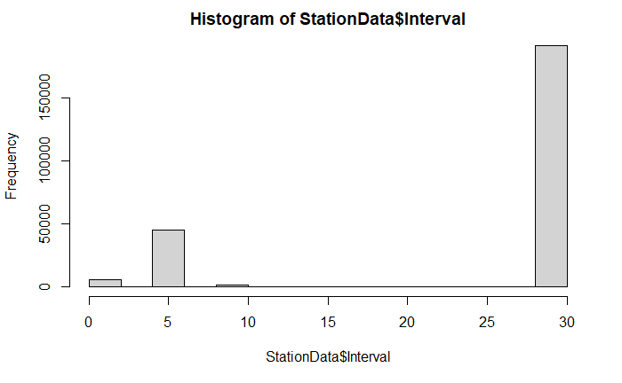

```r
# istogramma con le funzioni base di R
hist(StationData$Interval)
```

Qui Intervals conserva il suo valore numerico, lo vediamo dalla spaziatura dell’asse x.

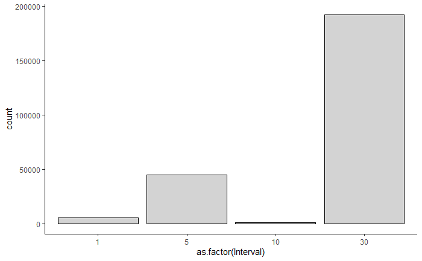

```r
# istogramma con ggplot di tidyverse
ggplot(StationData, aes(as.factor(Interval))) +
  geom_bar(fill='lightgrey',
           color='black') +
  theme_classic()
```

Qui invece Interval è giusto un’etichetta con la quale classificare i dati: le colonne dell’istogramma sono una accanto all’altra a prescindere dal valore dell’asse x.

*La maggior parte dei dati è alla mezz’ora, ma c’è un gruppo consistente anche a 5 minuti.*

**2. Quando troviamo dati con risoluzione al minuto?**

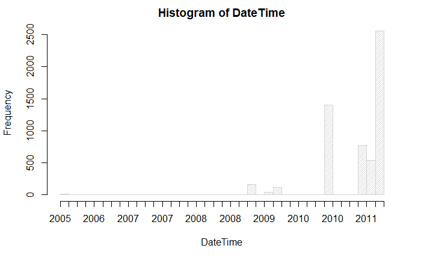

```r
# istogramma con le funzioni base di R
hist(StationData$DateTime[StationData$Interval==1],
     breaks = 30,
     xlab = "DateTime",    # x-axis label
     freq = T,             # switch to counts
     density = 40)         # grey-like fill (graphical parameter)
```

L’istogramma base per una variabile POSIXct è leggermente diverso da quello predefinito per una variabile numerica (si veda `?hist.POSIXt` contrapposto a `?hist` o `?hist.default`)

La funzione `geom_histogram()` crea un istogramma della variabile specificata in `aes()`, che può essere specificata nella chiamata principale di `ggplot()` o anche all’interno della funzione istogramma (la cosa ha effetti diversi solo in grafici con chiamate multiple alle funzioni grafiche).

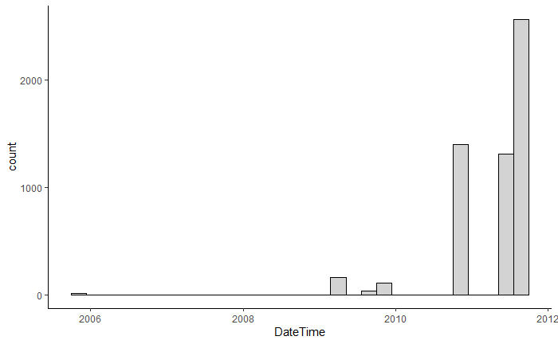

```r
# istogramma con le funzioni ggplot di tidyverse
StationData %>%
  filter(
    Interval == 1
  ) %>%
  ggplot(aes(DateTime)) +
  geom_histogram(bins = 30,
                 fill='lightgrey',
                 color='black') +
  theme_classic()
```

*Le misure al minuto terminano nel 2011.*

**3. Come sono distribuiti i dati alla mezz’ora rispetto ad anno e stagione?**

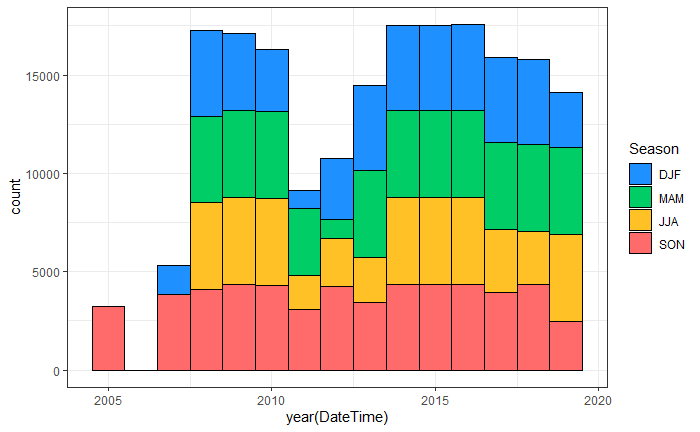

```r
StationData %>%
  filter(
    Interval == 30
  ) %>%
  ggplot(aes(year(DateTime), fill = Season)) +
  geom_histogram(binwidth = 1, color = "black") +
  # more colors at https://r-charts.com/colors/
  scale_fill_manual(values = c("DJF" = "dodgerblue1",
                               "MAM" = "springgreen3",
                               "JJA" = "goldenrod1",
                               "SON" = "indianred1")) +
  theme_bw()
```

Il parametro aggiuntivo `fill` dentro `aes()` permettere di suddividere le colonne dell’istogramma per stagione, andando a differenziare il colore di riempimento (“fill” appunto). I colori possono essere specificati con la famiglia di funzioni `scale_`. In questo caso per inserire i colori del riempimento manualmente uso `scale_fill_manual`. La legenda appare in automatico, utilizzando i nomi delle variabili in uso.

*Si noti un funzionamento discontinuo negli anni dal 2011 al 2013, mentre dal 2008 al 2010 e soprattutto dal 2014 al 2016 i dati sono uniformemente distribuiti tra le annate e le stagioni, per poi peggiorare leggermente negli anni più recenti.*

### Scatterplots

La funzione `geom_count()` è utile per scatterplots e simili, dove c’è rischio concreto di *overplotting*.

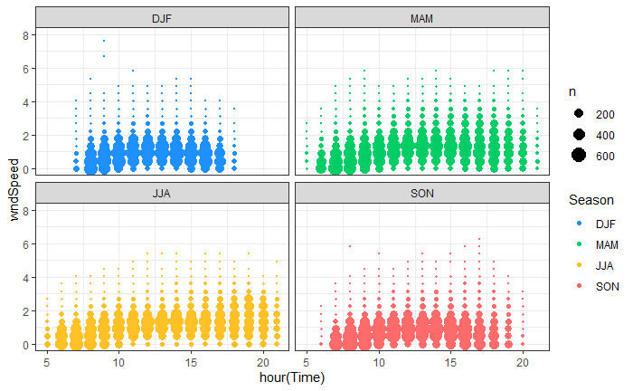

```r
# Un esempio di grafico con la suite ggplot2 preceduta da un filtro
StationData %>%
  filter(
    Interval == 30,
    Press > 800,
    outTemp > -30,
    outHum > 0,
    totRad > 0
  ) %>%
  ggplot(aes(hour(Time), wndSpeed, color = Season)) +
  geom_count() +
  facet_wrap(~Season) +               # divido in quattro box
  coord_cartesian(ylim = c(0, 8)) +  # taglio alcuni valori estremi

  scale_color_manual(values = c("DJF" = "dodgerblue1",
                                "MAM" = "springgreen3",
                                "JJA" = "goldenrod1",
                                "SON" = "indianred1")) +
  scale_size_area() +   # ensures that counts of zero would be given size 0
  theme_bw()
```

Di seguito lo stesso grafico, ottenuto però con la funzione `geom_point()` che è affetta da overplotting. In questo caso non si capisce quali punti siano più popolati di altri. Inoltre, il rendering della figura è molto rallentato, perché vengono disegnati inutilmente tantissimi punti.

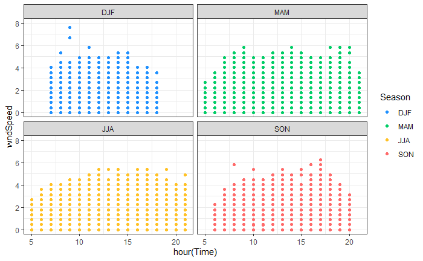

```r
StationData %>%
  filter(
    Interval == 30,
    Press > 800,
    outTemp > -30,
    outHum > 0,
    totRad > 0
  ) %>%
  ggplot(aes(hour(Time), wndSpeed, color = Season)) +
  geom_point() +                      # issue: overplotting
  facet_wrap(~Season) +               # divido in quattro box
  coord_cartesian(ylim = c(0, 8)) +  # taglio alcuni valori estremi

  scale_color_manual(values = c("DJF" = "dodgerblue1",
                                "MAM" = "springgreen3",
                                "JJA" = "goldenrod1",
                                "SON" = "indianred1")) +
  theme_bw()
```

Posso usare queste funzioni per mettere in relazione anche più di due variabili, sfruttando ad esempio una scala colore mappata in modo continuo su una terza grandezza. Anche in questo caso (come per il fill funzione della stagione), la specifica andrà inserita dentro ad `aes()`. Posso usare anche combinazioni di più variabili, sia sugli assi cartesiani, sia su quelli colore. Di seguito un grafico di esempio, senza particolare valore fisico:

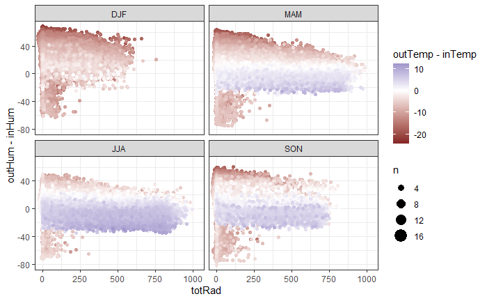

```r
StationData %>%
  filter(
    Interval == 30,
    wndSpeed >= 0,
    outHum >=0,
    outTemp > -50,
    inTemp > 0,
    totRad >=0
  ) %>%
  ggplot(aes(totRad, outHum-inHum, color = outTemp-inTemp)) +
  geom_count() +
  facet_wrap(~Season) +
  scale_color_gradient2() +   # diverging scale (red-blue) with white in the middle
  scale_size_area() +         # ensures that counts of zero would be given size 0
  theme_bw()
```

### Boxplots

Per analizzare distribuzioni di variabili continue rispetto a variabili discrete (formato: factor) posso utilizzare i **boxplots**, che mi mostrano varie informazioni statistiche raggruppate.

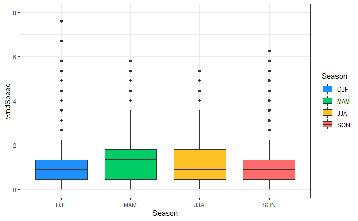

```r
# Un esempio di grafico con la suite ggplot2 preceduta da un filtro
StationData %>%
  filter(
    Interval == 30,
    Press > 800,
    outTemp > -30,
    outHum > 0,
    totRad > 0
  ) %>%
  ggplot(aes(Season, wndSpeed, fill = Season)) +
  geom_boxplot() +
  coord_cartesian(ylim = c(0, 8)) +  # taglio alcuni valori estremi

  scale_fill_manual(values = c("DJF" = "dodgerblue1",
                               "MAM" = "springgreen3",
                               "JJA" = "goldenrod1",
                               "SON" = "indianred1")) +
  theme_bw()
```

## Lavoro sui dati di VENTO

### Selezione dell’intervallo temporale

Imposto gli estremi dell’intervallo temporale di interesse tramite la funzione `as.POSIXct` che converte stringhe testuali in date e ore, specificando il formato in cui fornisco la stringa e il fuso orario (IMPORTANTE! di default verrebbe registrato come CET, ma meglio lavorare in UTC).

```r
# Uso le funzioni base:
startTime <- as.POSIXct("201401010030", format = "%Y%m%d%H%M", tz = "UTC")
endTime   <- as.POSIXct("201701010000", format = "%Y%m%d%H%M", tz = "UTC")

startTime
```

```
[1] "2014-01-01 00:30:00 UTC"
```

Se utilizzo le funzioni di tidyverse formato e timezone sono già impostati di default.

```r
# oppure quelle offerte dal pacchetto lubridate di tidyverse:
startTime <- ymd_hm("201401010030")
endTime   <- ymd_hm("201701010000")

startTime
```

```
[1] "2014-01-01 00:30:00 UTC"
```

Ho scelto gli anni 2014, 2015 e 2016 perché nell’istogramma esplorativo della distribuzione dei dati sono tre anni con un alto numero di dati, distribuito uniformemente tra le annate e tra le stagioni. Nel caso di un’analisi stagionale questo mi garantisce la necessaria omogeneità del dataset, mentre tre anni consecutivi permettono già di filtrare un po’ di segnale casuale della singola annata.

### Filtro semplice

Filtro i valori non verosimili della velocità del vento per l’intervallo prescelto.

```r
StationData %>%
  filter(
    DateTime >= startTime,
    DateTime <  endTime,

    Interval == 30, # seleziono solo misure a 30 minuti

    wndSpeed >= 0,
    wndSpeed <= 25,

    wndDir >= 0,
    wndDir < 360

  )%>%
  select(DateTime, wndDir, wndSpeed, Season) %>%
  head()
```

| DateTime | wndDir | wndSpeed | Season |
| --- | --- | --- | --- |
| 2014-01-01 00:30:00 | 202.5 | 0.447 | DJF |
| 2014-01-01 01:00:00 | 247.5 | 0.447 | DJF |
| 2014-01-01 01:30:00 | 247.5 | 0.447 | DJF |
| 2014-01-01 02:00:00 | 270.0 | 0.894 | DJF |
| 2014-01-01 02:30:00 | 270.0 | 0.894 | DJF |
| 2014-01-01 03:00:00 | 270.0 | 0.894 | DJF |

```r
NA
```

La potenza di `filter()` è gestire tanti filtri contemporaneamente e permettere aggiustamenti in tempo reale. Se voglio però analizzare in seguito la statistica dei dati filtrati di volta in volta, è meglio spezzare il procedimento in più steps.

```r
data0 <- StationData %>%
  filter(
    DateTime >= startTime,
    DateTime <  endTime
  )

data1 <- data0 %>%
  filter(
    Interval == 30 # seleziono solo misure a 30 minuti
  )

data2 <- data1 %>%
  filter(
    wndSpeed >= 0,
    wndSpeed <= 25,
  )

data3 <- data2 %>%
  filter(
    wndDir >= 0,
    wndDir < 360
  )

windData <- data3 %>% select(DateTime, wndDir, wndSpeed, Season)

head(windData)
```

| DateTime | wndDir | wndSpeed | Season |
| --- | --- | --- | --- |
| 2014-01-01 00:30:00 | 202.5 | 0.447 | DJF |
| 2014-01-01 01:00:00 | 247.5 | 0.447 | DJF |
| 2014-01-01 01:30:00 | 247.5 | 0.447 | DJF |
| 2014-01-01 02:00:00 | 270.0 | 0.894 | DJF |
| 2014-01-01 02:30:00 | 270.0 | 0.894 | DJF |
| 2014-01-01 03:00:00 | 270.0 | 0.894 | DJF |

```r
NA
```

### Filtro sulla persistenza

Elimino gli istanti in cui il vento non è nullo e non cambia per tre ore consecutive (comportamento indice di un probabile malfunzionamento dello strumento). Per farlo evito di usare `if` e `for` concatenati. Piuttosto creo dei vettori logici di supporto tramite funzioni ottimizzate a finestra mobile (dal pacchetto `zoo`) e li utilizzo per filtrare le righe. Vediamo:

Tramite la funzione `diff()` (R-base) calcolo lo step temporale tra righe distanti 5 posizioni (ovvero 2.5 ore, per un tot di 3h se consideriamo la riga selezionata). Se la serie temporale non è continua, il risultato sarà diverso da 2.5.

```r
Diff3h <- as.double(diff(windData$DateTime,lag = 5))
```

La funzione `diff()` restituisce, nelle impostazioni di default, un vettore di lunghezza pari al vettore originale meno il valore del lag, perché non considera sottoinsiemi del vettore minori del lag. Nel ritornare alla lunghezza originaria, apponendo dei `NA`, creo due versioni: una con “allineamento” dei risultati a destra dei valori selezionati, una a sinistra.

```r
# flag di continuità per 3 ore consecutive: (align = "left")
Diff3hL <- c(Diff3h, rep(NA, 5))

# flag di continuità per 3 ore consecutive: (align = "right")
Diff3hR <- c(rep(NA, 5), Diff3h)
```

L’operazione logica OR tra questi due vettori mi restituisce un flag di appartenenza ad una serie di 6 misure consecutive, a prescindere che siano prima o dopo l’intervallo selezionato.

```r
windData$whole3hours <- Diff3hL == 2.5 | Diff3hR == 2.5
```

Per creare un flag di costanza del vento, calcolo la deviazione standard in una finestra moble di sei righe (`width = 6`), che si sposta riga per riga (`by = 1`). Anche in questo caso creo due versioni del flag, una che restituisce il risultato allineato alla sinistra della finestra mobile, una alla sua destra. Il flag sarà nuovamente l’OR delle due.

```r
# flag di costanza della velocità in 3 ore (align = "left")
DiffWsL <- rollapply(windData$wndSpeed,
                     width = 6, by=1,
                     FUN = sd,
                     align = "left",
                     fill  = NA)

# flag di costanza della velocità in 3 ore (align = "right")
DiffWsR <- rollapply(windData$wndSpeed,
                     width = 6, by=1,
                     FUN = sd,
                     align = "right",
                     fill  = NA)


windData$constFlag <- DiffWsL == 0 | DiffWsR == 0
```

Viene lasciato da implementare lo stesso tipo di filtro per wndDir, dove si dovrà tenere conto della chiusura su sé stesso dell’angolo giro (360° –> 0°) e di come la risoluzione angolare impatti sulle condizioni di persistenza.

I dati da escludere sono quelli per i quali entrambi i flag siano `TRUE` e la velocità del vento non sia nulla (periodi di calma di vento persistenti non sono considerati inattendibili).

```r
windData_excl <- windData %>% filter(
  wndSpeed > 0,
  constFlag == T,
  whole3hours == T
)

head(windData_excl, 20)
```

| DateTime | wndDir | wndSpeed | Season | whole3hours | constFlag |
| --- | --- | --- | --- | --- | --- |
| 2014-01-02 22:00:00 | 292.5 | 1.341 | DJF | TRUE | TRUE |
| 2014-01-02 22:30:00 | 270.0 | 1.341 | DJF | TRUE | TRUE |
| 2014-01-02 23:00:00 | 292.5 | 1.341 | DJF | TRUE | TRUE |
| 2014-01-02 23:30:00 | 292.5 | 1.341 | DJF | TRUE | TRUE |
| 2014-01-03 00:30:00 | 270.0 | 1.341 | DJF | TRUE | TRUE |
| 2014-01-03 01:00:00 | 270.0 | 1.341 | DJF | TRUE | TRUE |
| 2014-01-03 01:30:00 | 270.0 | 1.341 | DJF | TRUE | TRUE |
| 2014-01-03 02:00:00 | 247.5 | 1.341 | DJF | TRUE | TRUE |
| 2014-01-03 07:30:00 | 292.5 | 1.341 | DJF | TRUE | TRUE |
| 2014-01-03 08:00:00 | 270.0 | 1.341 | DJF | TRUE | TRUE |

[output cut: 10 more lines]

Per esclusione tramite `setdiff()` creo il dataset filtrato, su cui lavorare.

```r
windData_filtered <- setdiff(windData, windData_excl)

head(windData_filtered, 20)
```

| DateTime | wndDir | wndSpeed | Season | whole3hours | constFlag |
| --- | --- | --- | --- | --- | --- |
| 2014-01-01 00:30:00 | 202.5 | 0.447 | DJF | TRUE | NA |
| 2014-01-01 01:00:00 | 247.5 | 0.447 | DJF | TRUE | NA |
| 2014-01-01 01:30:00 | 247.5 | 0.447 | DJF | TRUE | NA |
| 2014-01-01 02:00:00 | 270.0 | 0.894 | DJF | TRUE | NA |
| 2014-01-01 02:30:00 | 270.0 | 0.894 | DJF | TRUE | NA |
| 2014-01-01 03:00:00 | 270.0 | 0.894 | DJF | TRUE | FALSE |
| 2014-01-01 03:30:00 | 247.5 | 0.894 | DJF | TRUE | FALSE |
| 2014-01-01 04:00:00 | 225.0 | 0.447 | DJF | TRUE | FALSE |
| 2014-01-01 04:30:00 | 202.5 | 0.447 | DJF | TRUE | FALSE |
| 2014-01-01 05:00:00 | 202.5 | 0.447 | DJF | TRUE | FALSE |

[output cut: 10 more lines]

### Visualizzazione

#### Istogramma delle velocità del vento

Visualizzo ora un istogramma delle velocità filtrate. Posso salvare la chiamata a `ggplot()` in una variabile e stamparla in un secondo momento.

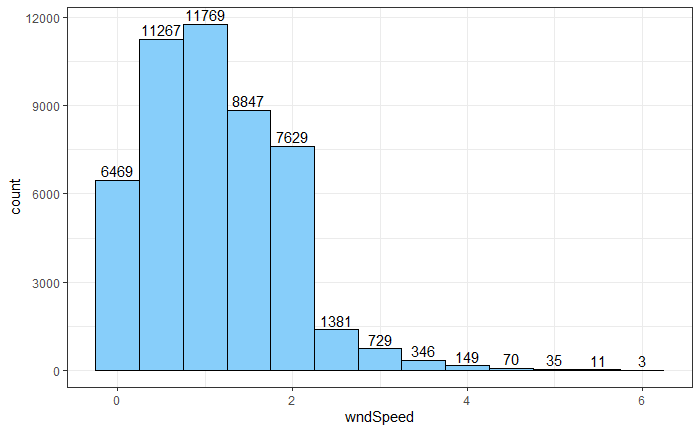

```r
fig1 <- windData_filtered %>%

  ggplot(aes(wndSpeed)) +

  geom_histogram(binwidth = 0.5,
                 fill='lightskyblue',
                 color='black') +
  stat_bin(binwidth=0.5, geom="text", aes(label=..count..), vjust=-0.3) +
  # scale_y_log10() +                  # logarithmic Y axis
  theme_bw()

fig1
```

Una volta salvata una figura, posso aggingere dei blocchi semplicemente con un `+`. Se non riassegno il risultato a `fig1`, il suo contenuto non cambia.

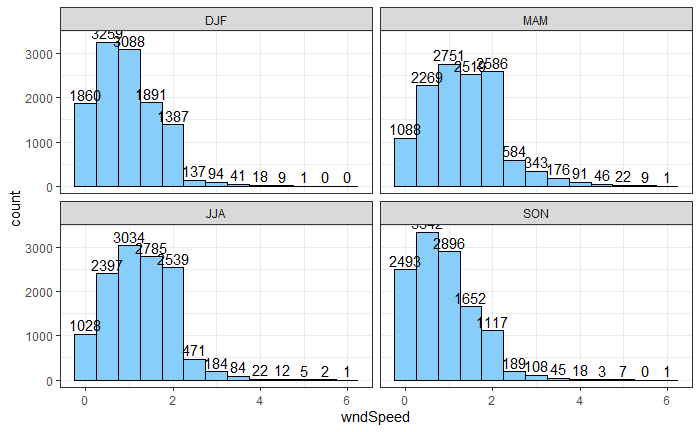

```r
fig1 + facet_wrap(~Season)
```

#### Consistency

Utilizzo la funzione seq() per creare una sequenza di tutti gli intervalli temporali compresi tra `startTime` e `endTime`. R gestisce automaticamente il calendario (lunghezza dei vari mesi, anni bisestili, ecc..).

```r
totalTime <- seq(startTime, endTime, by="30 min")
```

Calcolo quanti dati sono presenti ad ogni step di filtraggio.

```r
consTab <- data.frame(
  Total     = length(totalTime),
  Available = dim(data0)[1],
  halfHour  = dim(data1)[1],
  wsOK      = dim(data2)[1],
  wdOK      = dim(windData)[1],
  sd3hOK    = dim(windData_filtered)[1]
)

consTab
```

| Total | Available | halfHour | wsOK | wdOK | sd3hOK |
| --- | --- | --- | --- | --- | --- |
| 52608 | 52600 | 52600 | 52600 | 52488 | 48705 |

Calcolo le percentuali di dati rimasti dopo ogni step successivo di filtraggio (sempre rispetto al totale iniziale). Potrei facilmente calcolare anche le percentuali relative ad ogni step precedente.

```r
percTab <- round(consTab/consTab$Total*100, 2)
percTab
```

| Total | Available | halfHour | wsOK | wdOK | sd3hOK |
| --- | --- | --- | --- | --- | --- |
| 100 | 99.98 | 99.98 | 99.98 | 99.77 | 92.58 |

*Il grosso dei dati filtrati viene escluso dal filtro sulla persistenza.*

Analizziamo ora l’andamento **mensile** delle percentuali di istanti di funzionamento della strumentazione (dati validi) rispetto al totale degli istanti disponibili.

Posso usare la funzione `hist()` anche per ricavare binning di variabili continue, impostando `plot = F` e assegnando il risultato ad una nuova variabile. Per fare la stessa cosa con le funzioni di tidyverse invece dovrei cambiare la chiamata da `geom_histogram()` a `stat_bin()` (vedi `?geom_freqpoly`).

```r
monTot <- hist(month(totalTime),
               plot = F,
               breaks = 0.5:12.5)
monTot
```

```
$breaks
 [1]  0.5  1.5  2.5  3.5  4.5  5.5  6.5  7.5  8.5  9.5 10.5 11.5 12.5

$counts
 [1] 4464 4080 4464 4320 4464 4320 4464 4464 4320 4464 4320 4464

$density
 [1] 0.08485401 0.07755474 0.08485401 0.08211679 0.08485401 0.08211679 0.08485401 0.08485401 0.08211679
[10] 0.08485401 0.08211679 0.08485401

$mids
 [1]  1  2  3  4  5  6  7  8  9 10 11 12

$xname
[1] "month(totalTime)"

$equidist
[1] TRUE

attr(,"class")
[1] "histogram"
```

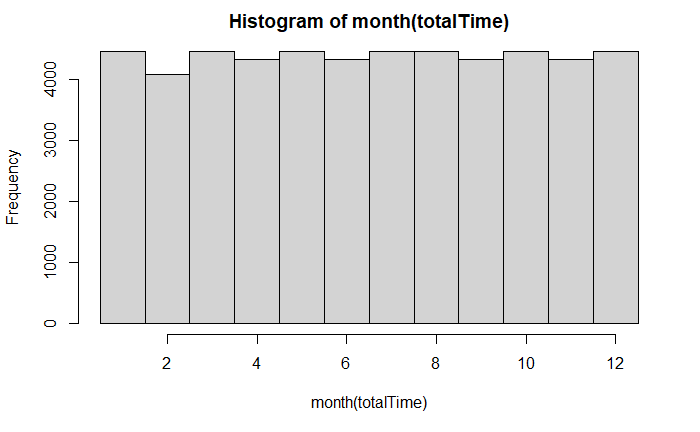

```r
plot(monTot)
```

Ripeto per la serie temporale degli intervalli del dataset filtrato.

```r
monPop    <- hist(month(windData_filtered$DateTime),
                  plot = F,
                  breaks = 0.5:12.5)
```

Creo l’istogramma delle percentuali di dati validi suddivise per mese.

In R posso indicare il risultato di un’operazione direttamente come colonna di una tibble, che a sua volta viene passata dal pipe `%>%` come variabile `data` per `ggplot`.

I nomi di colonne con caratteri speciali (in questo caso: spazi, parentesi e simbolo di percentuale) devono essere scritti tra accenti “`” per funzionare nelle chiamate di aes(). In questo modo la sintassi è leggermente più complessa ma l’etichetta degli assi è già pronta in formato leggibile e con l’unità di misura (in questo caso “%”).

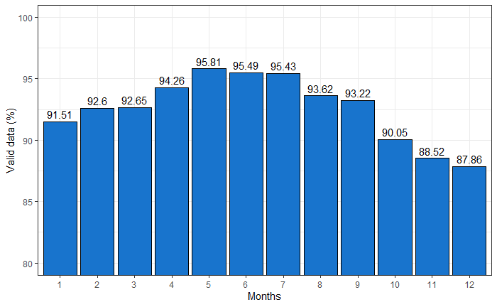

```r
fig2 <- tibble(Months = as.factor(monPop$mids),
               `Valid data (%)` = 100*monPop$counts/monTot$counts) %>%

  ggplot(aes(Months, `Valid data (%)` )) +

  geom_col(fill='dodgerblue3',
           color='black') +
  geom_text(aes(label=round(`Valid data (%)`, 2)), vjust=-0.4) +
  coord_cartesian(ylim = c(80,100)) + # zoom at high percentages
  theme_bw()

fig2
```

### Statistiche

Nel confrontare più stazioni è possibile sfruttare le funzioni statistiche di R. Correlazione e covarianza sono ovviamente già implementate nel linguaggio, così come molti modelli di fit, lineari e non.

Creo un dataset fittizio per lanciare le funzioni di esempio.

```r
windD <- windData_filtered %>%
  mutate(wndSpeed2 = wndSpeed *                          # Add random noise
           rnorm(n = length(windData_filtered$DateTime), # (multiplicative)
                 mean = 1,
                 sd = 0.2) +
           rnorm(n = length(windData_filtered$DateTime), # (additive)
                 mean = 0,
                 sd = 0.3)
  ) %>%
  mutate(
    wndSpeed2 = 0.447 * (wndSpeed2 %/% 0.447)            # Original resolution
  ) %>%
  filter(
    wndSpeed > 0,                                        # Only non-zero entries
    wndSpeed2 >= 0
  )
```

Calcolo correlazione e altre statistiche continue tramite una funzione che definisco una volta per tutte.

```r
statsFun <- function(Var, Ref){
  avgR <- mean(Ref)
  SMP  <- length(na.omit(Var))
  COR  <- cor(Var, Ref, use = "pairwise.complete.obs")
  ME   <- mean(Var - Ref, na.rm = T)
  MAE  <- mean(abs(Var - Ref), na.rm = T)
  RMSE <- sqrt(mean((Var - Ref)^2, na.rm = T))
  MAX  <- max(Var, na.rm = T)
  nME  <- ME/avgR
  nMAE <- MAE/avgR
  CV   <- RMSE/avgR

  table <- data.frame(SMP, avgR, nME, nMAE, CV, COR, ME, MAE, RMSE, MAX)

  return(signif(table, 3))
}


results <- statsFun(windD$wndSpeed2, windD$wndSpeed)
results
```

| SMP | avgR | nME | nMAE | CV | COR | ME | MAE | RMSE | MAX |
| --- | --- | --- | --- | --- | --- | --- | --- | --- | --- |
| 41300 | 1.21 | -0.17 | 0.28 | 0.386 | 0.86 | -0.207 | 0.34 | 0.469 | 7.6 |

```r
# Pearson's Correlation Coefficient (CC or R)
results$COR
```

```
[1] 0.86
```

```r
# Coefficient of Variation (CV)
results$CV
```

```
[1] 0.386
```

```r
# normalized Mean Error (or Bias)
results$nME
```

```
[1] -0.17
```

Calcolo il modello lineare per il fit dei dati sullo scatterplot. Gli oggetti `lm` sono ricchi di informazioni statistiche sulla significatività del modello.

```r
fitLM <- lm(formula = wndSpeed2~wndSpeed, data = windD)
summary(fitLM)
```

```
Call:
lm(formula = wndSpeed2 ~ wndSpeed, data = windD)

Residuals:
    Min      1Q  Median      3Q     Max
-2.8393 -0.2500  0.1838  0.2103  2.9717

Coefficients:
             Estimate Std. Error t value Pr(>|t|)
(Intercept) -0.170568   0.004007  -42.56   <2e-16 ***
wndSpeed     0.970381   0.002829  343.00   <2e-16 ***
---
Signif. codes:  0 ‘***’ 0.001 ‘**’ 0.01 ‘*’ 0.05 ‘.’ 0.1 ‘ ’ 1

Residual standard error: 0.4202 on 41338 degrees of freedom
Multiple R-squared:   0.74, Adjusted R-squared:   0.74
F-statistic: 1.176e+05 on 1 and 41338 DF,  p-value: < 2.2e-16
```

Ricavo l’equazione dai coefficienti:

```r
textLM <- paste0("y = ",round(fitLM$coefficients[1],digits=2),
                 " + ",round(fitLM$coefficients[2],digits=2)," x")
textLM
```

```
[1] "y = -0.17 + 0.97 x"
```

Creo lo scatterplot di confronto tra stazioni. Posso disegnare il fit sia con la funzione `geom_smooth(method = "lm")` di ggplot, sia tracciando una retta con `geom_abline()` e impostando `slope` e `intercept` secondo i coefficienti di `lm()`. L’unica differenza è che la prima disegna il fit solo all’interno dell’intervallo dei dati (linea rossa piena), mentre la seconda si estende anche oltre (linea rossa tratteggiata).

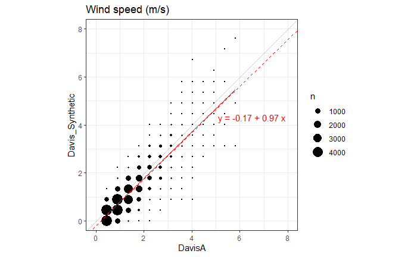

```r
fig4 <- windD %>%
  ggplot(aes(wndSpeed, wndSpeed2)) +
  geom_count() +
  scale_size_area() +
  geom_smooth(method = 'lm', se = T, colour = 'red', size=0.6) +
  geom_abline(slope = fitLM$coefficients[2],
              intercept = fitLM$coefficients[1], linetype = 2, colour = 'red') +
  annotate('text', x=6.5, y=4.3, label = textLM, color="red") +
  ggtitle("Wind speed (m/s)") +
  xlab('DavisA') +
  ylab('Davis_Synthetic') +
  geom_abline(slope = 1, intercept = 0, alpha = 0.2) +
  coord_fixed(xlim = c(0,8),
              ylim = c(0,8)) +
  theme_bw()

fig4
```

### Outputs

#### RData archive (formato standard di R)

Salvo i dataset (escluso e filtrato) per poterli recuperare successivamente. Posso salvare più variabili nello stesso archivio compresso tramite la funzione `save()`.

```r
save(windData_filtered, windData_excl, file = filenames$output.windData)
```

Il file `.RData` pesa molto meno dei files txt o csv e viene letto e scritto più rapidamente.

#### Immagini PNG

Salvo le figure in formato PNG tramite la funzione `ggsave()`, richiamando le variabili dei plot salvate precedentemente. Alternativamente potrei chiamare ggsave() appena dopo ogni plot, senza specificare il parametro `plot` che di default ha il valore `last_plot()`, cioè salva l’ultima figura creata da `ggplot()`.

```r
ggsave(filenames$figure.HistWS, plot = fig1)
ggsave(filenames$figure.DataConsistency, plot = fig2)

ggsave(filenames$figure.ScatterPlot, plot = fig4)
```

#### File testuale TXT (per WRPLOT)

Preparo un file da dare in input al software per la visualizzazione interattiva delle rose dei venti.

WRPlot accetta solo dati orari (nel caso di più misure relative alla stessa ora, considera solo la prima). Di seguito il filtro per selezionare solo dati orari. Si potrebbe anche decidere di aggregare i dati a risoluzione più alta (ad es. 30 min) con una media (si vedano al proposito gli strumenti suggeriti nell’appendice 1).

```r
windData_filtered_hourly <- windData_filtered %>%
  filter(minute(DateTime) == 0)
```

Il dataset orario viene formattato secondo i requisiti del programma.

```r
toLAKES <- tibble(
  StID = rep(99999,dim(windData_filtered_hourly)[1]),      # Station ID (flag)

  YYYY = year (windData_filtered_hourly$DateTime),         # year
  MM   = month(windData_filtered_hourly$DateTime),         # month
  DD   = day  (windData_filtered_hourly$DateTime),         # day
  HH   = hour (windData_filtered_hourly$DateTime),         # hour

  Dir  = round(windData_filtered_hourly$wndDir, digits=0), # Rounded Wind Direction
  WS   = round(1.94384*windData_filtered_hourly$wndSpeed, digits=0) # Rounded Wind Speed
  # (1 knot = 1.94384 m/s)
)

head(as.matrix(toLAKES))
```

```
      StID YYYY MM DD HH Dir WS
[1,] 99999 2014  1  1  1 248  1
[2,] 99999 2014  1  1  2 270  2
[3,] 99999 2014  1  1  3 270  2
[4,] 99999 2014  1  1  4 225  1
[5,] 99999 2014  1  1  5 202  1
[6,] 99999 2014  1  1  6 248  1
```

Creo il file di output con lintestazione e scrivo i dati. Il parametro `append = TRUE` mi garantisce che l’intestazione non venga sovrascritta.

```r
# Append the "LAKES FORMAT" string at the beginning of the file
fileConn<-file(paste0(resfolder, StationDataRootName,"_LAKES.txt"))
writeLines(c("LAKES FORMAT"), fileConn)
close(fileConn)

# Export to a LAKES-formatted file
write.table(toLAKES, paste0(resfolder, StationDataRootName,"_LAKES.txt"),
            sep = " ", row.names=FALSE, col.names=FALSE, append =TRUE)
```

### Confronto dati DIFA - Arpae

I dati delle stazioni della rete regionale sono **scaricabili liberamente** dalla piattaforma dext3r (https://simc.arpae.it/dext3r/) selezionando il periodo e le variabili prescelte.

Nella **lettura dei dati** con `read_table` bisogna specificare manualmente le righe da leggere, partendo dalla riga dei nomi colonna (compresa) ed arrivando alle righe di descrizione della stazione in coda al file (escluse). Utilizzare i parametri `skip` e `n_mmax`.

```r
BoUrbana_wndSpeed <- read_csv(
  # paste0(datafolder, "dexter-0717a628-12b6-4fac-a50b-5861c06b13ea.csv"),
  paste0(datafolder, "dexter-1fd532da-66e3-4154-bd5d-4f67a0a530b9.csv"),
  skip  = 3,  # salto le prime tre righe di intestazione
  n_max = 75,  # salto le righe finali coi dati della stazione
  col_types = cols(
    `Fine validità (UTC)`   = col_datetime(format = "%Y-%m-%d %H:%M:00+00:00"),
    `Inizio validità (UTC)` = col_datetime(format = "%Y-%m-%d %H:%M:00+00:00")))

colnames(BoUrbana_wndSpeed) <- c('Init', 'DateTime', 'wndSpeed')
BoUrbana_wndSpeed <- select(BoUrbana_wndSpeed, DateTime, wndSpeed)
```

I dati delle stazioni di UniBo sono in ora locale (timezone CET e CEST in base alla stagione). Per il confronto con BolognaUrbana (timezone UTC) bisogna **convertirli** con il comando `force_tz()`.

```r
windData_filtered$DateTime <- force_tz(windData_filtered$DateTime, "Europe/Rome")
```

Per un confronto efficace bisogna garantire la **corrispondenza temporale** dei due datasets. Anche in questo caso, al posto di scrivere condizioni *if* innestate in cicli *for*, utilizzo una funzione di `dplyr` ottimizzata per questa task: `inner_join(..., by = DateTime)`

```r
combData <- inner_join(select(windData_filtered, DateTime, wndSpeed), BoUrbana_wndSpeed,
                       by = "DateTime",
                       suffix = c("_Davis", "_BoUrb"))

combData %>%  head(10)
```

| DateTime | wndSpeed_Davis | wndSpeed_BoUrb |
| --- | --- | --- |
| 2015-06-01 00:00:00 | 0.447 | 0.8 |
| 2015-06-01 01:00:00 | 0.000 | 2.3 |
| 2015-06-01 02:00:00 | 0.000 | 2.5 |
| 2015-06-01 03:00:00 | 0.000 | 2.1 |
| 2015-06-01 04:00:00 | 0.000 | 2.9 |
| 2015-06-01 05:00:00 | 0.447 | 2.6 |
| 2015-06-01 06:00:00 | 0.447 | 2.8 |
| 2015-06-01 07:00:00 | 0.894 | 2.3 |
| 2015-06-01 08:00:00 | 0.894 | 1.6 |
| 2015-06-01 09:00:00 | 0.894 | 2.0 |

I dati così formattati sono già pronti per uno **scatterplot** (a puro scopo di esempio).

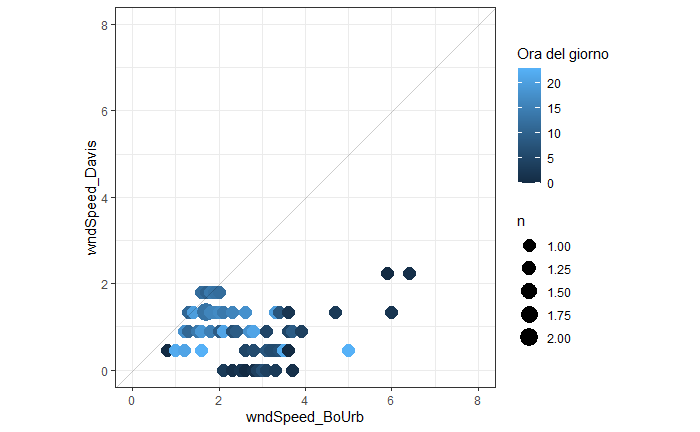

```r
ggplot(combData, aes(wndSpeed_BoUrb, wndSpeed_Davis, color = hour(DateTime))) +
  geom_count() +
  geom_abline(slope = 1, intercept = 0, alpha = 0.2) +
  scale_size_area() +
  coord_fixed(xlim = c(0,8),
              ylim = c(0,8)) +
  labs(color = "Ora del giorno") +
  theme_bw()
```

Potete poi procedere per i confronti con tutti gli strumenti grafici e statistici che abbiamo già presentato nelle sezioni precedenti.

Fine. Buon lavoro!

## Appendice 1

### Manipolazione dei dati

#### Tidy data e pivoting

Posso però riscrivere i dati in **formato tidy** per un migliore confronto grafico delle serie temporali tramite la funzione `pivot_longer`: le due stazioni passano da nomi di colonna a factors di una nuova colonna “Stazione”.

```r
tidyData <- combData %>%

  rename(Davis = wndSpeed_Davis,
         BoUrb = wndSpeed_BoUrb
  ) %>%

  pivot_longer(cols = 2:3,
               names_to = "Stazione",
               values_to = "wndSpeed")

tidyData %>% head(10)
```

| DateTime | Stazione | wndSpeed |
| --- | --- | --- |
| 2015-06-01 00:00:00 | Davis | 0.447 |
| 2015-06-01 00:00:00 | BoUrb | 0.800 |
| 2015-06-01 01:00:00 | Davis | 0.000 |
| 2015-06-01 01:00:00 | BoUrb | 2.300 |
| 2015-06-01 02:00:00 | Davis | 0.000 |
| 2015-06-01 02:00:00 | BoUrb | 2.500 |
| 2015-06-01 03:00:00 | Davis | 0.000 |
| 2015-06-01 03:00:00 | BoUrb | 2.100 |
| 2015-06-01 04:00:00 | Davis | 0.000 |
| 2015-06-01 04:00:00 | BoUrb | 2.900 |

In questo modo il confronto delle **serie temporali** è immediato impostando `aes(color = Stazione)`.

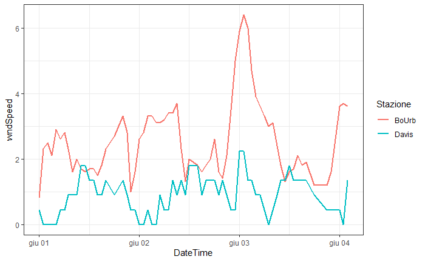

```r
ggplot(tidyData, aes(DateTime, wndSpeed, color = Stazione)) +
  geom_line(size = 0.8) +
  theme_bw()
```

Così come per le **distribuzioni**.

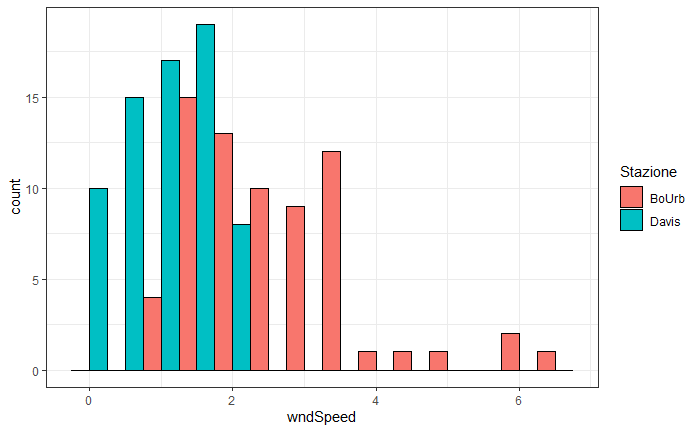

```r
ggplot(tidyData, aes(wndSpeed, fill = Stazione)) +
  geom_histogram(binwidth = 0.5, position = "dodge", color = "black") +
  # geom_freqpoly(binwidth = 0.5) +
  theme_bw()
```

#### Statistiche aggregate

```r
# Creo una stringa univoca per ogni ora
windData_filtered$DateTimeH <- date(windData_filtered$DateTime) + hour(windData_filtered$DateTime)

windData_filtered %>%
  group_by(DateTimeH) %>%
  summarise(HourlyAvg = mean(wndSpeed)) %>% head(10)
```

| DateTimeH | HourlyAvg |
| --- | --- |
| 2014-01-01 | 0.4470000 |
| 2014-01-02 | 0.4470000 |
| 2014-01-03 | 0.7152000 |
| 2014-01-04 | 0.6705000 |
| 2014-01-05 | 0.9436667 |
| 2014-01-06 | 1.0057500 |
| 2014-01-07 | 1.0536429 |
| 2014-01-08 | 0.7543125 |
| 2014-01-09 | 0.7450000 |
| 2014-01-10 | 0.5411053 |

```r
NA
```

Oppure posso calcolare le velocità medie giornaliere, raggruppando secondo `date(DateTime)`. Questo comando permette di identificare univocamente ogni giornata ed aggregare le ore all’interno di essa.

Attenzione perché se invece avessimo usato ad esempio `day(DateTime)`, il programma andrebbe a raggruppare assieme tutti i giorni 1, 2, 3, etc.. di ogni mese, perdendo la differenziazione mensile ed annuale (avremo cioè un dataset finale di 31 righe). Fondamentale quindi è individuare il parametro corretto su cui raggruppare.

```r
windData_filtered %>%
  group_by(date(DateTime)) %>%
  summarise(DailyAvg = mean(wndSpeed)) %>% head(10)
```

| date(DateTime) | DailyAvg |
| --- | --- |
| 2014-01-01 | 0.7323191 |
| 2014-01-02 | 1.0362273 |
| 2014-01-03 | 1.1510250 |
| 2014-01-04 | 1.0895625 |
| 2014-01-05 | 1.2632609 |
| 2014-01-06 | 0.8269500 |
| 2014-01-07 | 0.5135745 |
| 2014-01-08 | 0.4054186 |
| 2014-01-09 | 0.4693500 |
| 2014-01-10 | 0.5215000 |

```r
NA
```

#### Daily Wind

Utilizzo queste funzioni di manipolazione per ottenere rapidamente la figura “DailyWind” dove si analizza il ciclo diurno/notturno del vento. In questo caso il parametro di raggruppamento è `hour(DateTime)` e le statistiche necessarie sono la media e la deviazione standard del vento e la media delle direzioni (da interpretare però con attenzione..).

Aggiungo un coefficiente di scaling per mostrare entrambe le grandezze nello stesso plot.

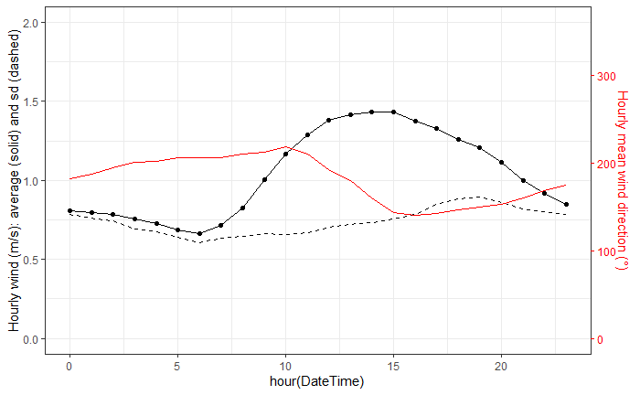

```r
vmax  <- 2                          # fixed max value for y-axis
coeff <- 360/vmax                   # scaling of the second axis and variable

fig3 <- windData_filtered %>%
  group_by(
    hour(DateTime)
  ) %>%
  summarise(
    HourlyAvg = mean(wndSpeed),
    HourlyStDev = sd(wndSpeed),
    HourlyWDir = mean(wndDir),
  ) %>%

  ggplot(aes(`hour(DateTime)`, HourlyAvg)) +
  geom_line() +
  geom_point() +
  geom_line(aes(y=HourlyStDev), linetype = "dashed") +
  geom_line(aes(y=HourlyWDir/coeff), color = "red") +

  coord_cartesian(ylim = c(0, vmax)) +
  scale_y_continuous(
    name     = "Hourly wind (m/s): average (solid) and sd (dashed)",
    sec.axis = sec_axis(~.*coeff, name="Hourly mean wind direction (°)")
  ) +

  theme_bw() +
  theme(
    axis.title.y.right = element_text(color = "red"),
    axis.text.y.right  = element_text(color = "red"),
    axis.ticks.y.right = element_line(color = "red")
  )

ggsave(filenames$figure.DailyWind, plot = fig3)

fig3
```

In questo caso, per differenziare secondo la stagione non basta aggiungere `+ facet_wrap(~Season)` perché la variabile Season non è stata conservata da `summarise()`. Bisogna quindi riscrivere la funzione, aggiungendo Season in `group_by()`.

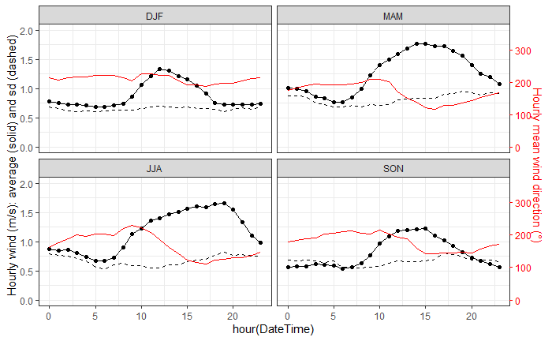

```r
windData_filtered %>%
  group_by(
    hour(DateTime),
    Season                     # now the Season information is kept
  ) %>%
  summarise(
    HourlyAvg = mean(wndSpeed),
    HourlyStDev = sd(wndSpeed),
    HourlyWDir = mean(wndDir),
  ) %>%

  ggplot(aes(`hour(DateTime)`, HourlyAvg)) +
  geom_line() +
  geom_point() +
  geom_line(aes(y=HourlyStDev), linetype = "dashed") +
  geom_line(aes(y=HourlyWDir/coeff), color = "red") +

  facet_wrap(~Season) +        # and the plot faceting works

  coord_cartesian(ylim = c(0, vmax)) +
  scale_y_continuous(
    name     = "Hourly wind (m/s): average (solid) and sd (dashed)",
    sec.axis = sec_axis(~.*coeff, name="Hourly mean wind direction (°)")
  ) +

  theme_bw() +
  theme(
    axis.title.y.right = element_text(color = "red"),
    axis.text.y.right  = element_text(color = "red"),
    axis.ticks.y.right = element_line(color = "red")
  )
```

## Appendice 2

### Verifica del fuso orario dei dati delle stazioni Davis tramite il confronto con la stazione di Bologna Urbana dei dati di radiazione solare.

#### 1. Acquisizione dati

Seleziono due intervalli di pochi giorni, uno in estate e uno in inverno per valutare la presenza dell’ora legale, e scarico i dati di radiazione solare da dext3r per la stazione Bologna Urbana.

```r
stSum <- ymd_hm("201506010030")
enSum <- ymd_hm("201506040000")

stWin <- ymd_hm("201512010030")
enWin <- ymd_hm("201512040000")

DavisSum <- StationData %>%
  select(DateTime, totRad) %>%
  filter(DateTime >= stSum,
         DateTime <  enSum)

DavisWin <- StationData %>%
  select(DateTime, totRad) %>%
  filter(DateTime >= stWin,
         DateTime <  enWin)

BoUrbSum <- read_csv(
  paste0(datafolder, "dexter-540faa09-8ed4-4cd1-a3fb-bb9abb0befcc.csv"),
  skip  = 3,
  n_max = 75,
  col_types = cols(
    `Fine validità (UTC)`   = col_datetime(format = "%Y-%m-%d %H:%M:00+00:00"),
    `Inizio validità (UTC)` = col_datetime(format = "%Y-%m-%d %H:%M:00+00:00")))

colnames(BoUrbSum) <- c('Init', 'DateTime', 'totRad')

BoUrbSum <- BoUrbSum %>% select(DateTime, totRad)


BoUrbWin <- read_csv(
  paste0(datafolder, "dexter-883c06b6-e7ab-47a5-94f0-40c0b61d6f3f.csv"),
  skip  = 3,
  n_max = 73,
  col_types = cols(
    `Fine validità (UTC)`   = col_datetime(format = "%Y-%m-%d %H:%M:00+00:00"),
    `Inizio validità (UTC)` = col_datetime(format = "%Y-%m-%d %H:%M:00+00:00")))

colnames(BoUrbWin) <- c('Init', 'DateTime', 'totRad')

BoUrbWin <- BoUrbWin %>% select(DateTime, totRad)
```

#### 2. Controllo visivo

Confronto le serie temporali estive e invernali plottando le curve dei valori di totRad.

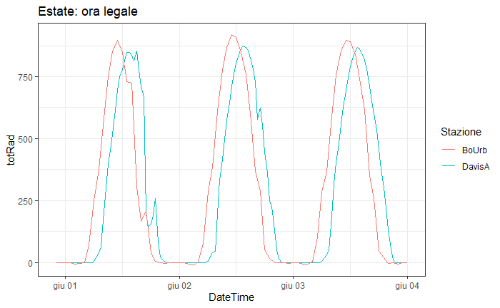

```r
a <- DavisSum %>%
  ggplot(aes(DateTime, totRad, color = "DavisA")) +
  geom_line() +
  labs(colour = "Stazione",
       title = "Estate: ora legale") +
  theme_bw()

a + geom_line(data = BoUrbSum,
              aes(DateTime, totRad, color = "BoUrb"))
```

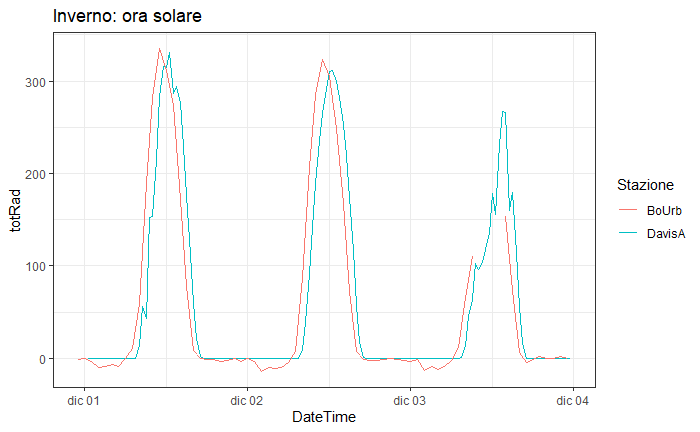

```r
b <- DavisWin %>%
  ggplot(aes(DateTime, totRad, color = "DavisA")) +
  geom_line() +
  labs(colour = "Stazione",
       title = "Inverno: ora solare") +
  theme_bw()

b + geom_line(data = BoUrbWin,
              aes(DateTime, totRad, color = "BoUrb"))
```

*Sono evidenti gli sfasamenti tra i dati di Bologna Urbana (UTC) e i dati della stazione Davis. In estate lo sfasamento è maggiore (CEST = UTC + 2) rispetto all’inverno (CET = UTC + 1)*

#### 3. Controllo numerico

Cerco la conferma stampando l’ora dei massimi.

```r
DavisSum %>%
  group_by(day(DateTime)) %>%
  filter(totRad == max(totRad))
```

| DateTime | totRad | day(DateTime) |
| --- | --- | --- |
| 2015-06-01 15:00:00 | 853 | 1 |
| 2015-06-02 13:30:00 | 875 | 2 |
| 2015-06-03 13:30:00 | 869 | 3 |

```r
NA
```

```r
DavisWin %>%
  group_by(day(DateTime)) %>%
  filter(totRad == max(totRad))
```

| DateTime | totRad | day(DateTime) |
| --- | --- | --- |
| 2015-12-01 12:30:00 | 331 | 1 |
| 2015-12-02 12:30:00 | 311 | 2 |
| 2015-12-03 13:30:00 | 267 | 3 |

```r
BoUrbSum %>%
  group_by(day(DateTime)) %>%
  filter(totRad == max(totRad))
```

| DateTime | totRad | day(DateTime) |
| --- | --- | --- |
| 2015-05-31 22:00:00 | -2 | 31 |
| 2015-05-31 23:00:00 | -2 | 31 |
| 2015-06-01 11:00:00 | 896 | 1 |
| 2015-06-02 11:00:00 | 919 | 2 |
| 2015-06-03 11:00:00 | 896 | 3 |
| 2015-06-04 00:00:00 | -2 | 4 |

```r
NA
```

```r
BoUrbWin %>%
  group_by(day(DateTime)) %>%
  filter(totRad == max(totRad))
```

| DateTime | totRad | day(DateTime) |
| --- | --- | --- |
| 2015-11-30 23:00:00 | -1 | 30 |
| 2015-12-01 11:00:00 | 335 | 1 |
| 2015-12-02 11:00:00 | 323 | 2 |

```r
NA
```

#### 4. Correzione

Implemento la correzione tramite la funzione `force_tz()`.

```r
StationData$DateTime <- force_tz(StationData$DateTime, "Europe/Rome")
```

#### 5. Verifica

Ricreo i due grafici precedenti:

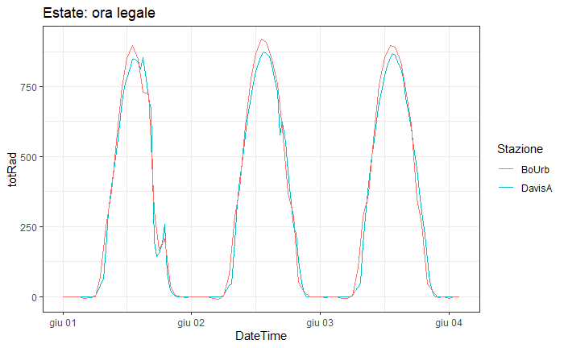

```r
StationData %>%
  select(DateTime, totRad) %>%
  filter(DateTime >= stSum,
         DateTime <  enSum) %>%
  ggplot(aes(DateTime, totRad, color = "DavisA")) +
  geom_line() +
  labs(colour = "Stazione",
       title = "Estate: ora legale") +
  geom_line(data = BoUrbSum,
            aes(DateTime, totRad, color = "BoUrb")) +
  theme_bw()
```

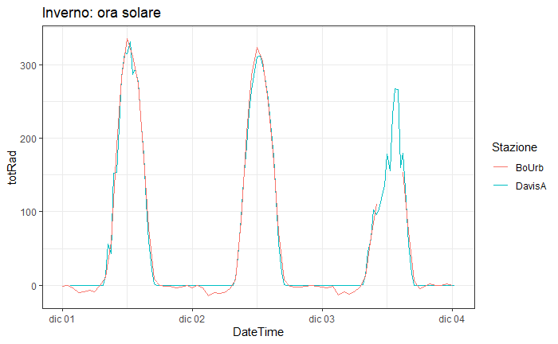

```r
StationData %>%
  select(DateTime, totRad) %>%
  filter(DateTime >= stWin,
         DateTime <  enWin) %>%
  ggplot(aes(DateTime, totRad, color = "DavisA")) +
  geom_line() +
  labs(colour = "Stazione",
       title = "Inverno: ora solare") +
  geom_line(data = BoUrbWin,
            aes(DateTime, totRad, color = "BoUrb")) +
  theme_bw()
```

*Ora l’allineamento è perfetto!*

**N.B.**

Definire la time zone non come “CET” o “CEST” ma come **“Europe/Rome”** permette di gestire in automatico il cambio tra ora solare e ora legale.

Fine. (bis)